# RNG and PRNG

## Goals

1. Understand that random numbers on computers are almost always deterministic.
2. Become familiar with the Random package interface for working with random devices.
3. Understand the principles underlying the LCG and appreciate the universality of the standard uniform distribution.

## Overview

- What is randomness? Humans talk about randomness in terms of absence of certain qualities, namely *discernable patterns* or *predictability*.
- Without a *physical source of randomness*, truly random numbers are expensive.
- Computers use PRNG, deterministic algorithms, to simulate different patterns of randomness.
- Pseudo-Random Number Generation (PRNG). Sometimes referred to RNG; the Pseudo is implicit.

## The `Random` Interface

Random number generation on a computer is, with few exceptions, an entirely deterministic procedure. Starting from a particular state, different PRNG algorithms yield reproducible streams of seemingly random numbers. The [Random](https://docs.julialang.org/en/v1.12/stdlib/Random/) package in the standard library provides an interface for PRNG in Julia.

```julia
using Random
```

Julia allows us to create our own *random devices* for PRNG. The default in Julia is now [`Xoshiro`](https://prng.di.unimi.it/), but there are others such as `MersenneTwister` that are used in R.

```julia
myrng = Xoshiro()
```

```
Xoshiro(0x509b61903a5f1c02, 0x70c361f6fca1faf4, 0xe25cdea476dd8f86, 0x91cc2322668b9887, 0x0b4ad69c506a062d)
```

Different PRNGs will use different abstractions to represent state. The state of this particular PRNG appears to be based on a few different variables:

```julia
myrng.s0
myrng.s1 # and so on...
```

### The `rand()` function

To sample from a PRNG we again use `rand()`. This is the only sampling function we need in most cases. There is a non-allocation version, `rand!()` which can be used to store data in an array.

```julia
rand(myrng)
```

```
0.6637548754218311
```

```julia
rand(myrng, Int)
```

```
7266711163670654912
```

```julia
rand(myrng, 10)
```

```
10-element Vector{Float64}:
 0.06843349318856207
 0.3805454337220123
 0.9834313991440706
 0.13824912613553453
 0.44726471428457826
 0.17759955113381598
 0.07344800272636931
 0.6554613875144026
 0.15260493825513732
 0.5665438897504956
```

### Shuffling

The `randperm()` and `randperm!()` functions generates a random permutation. It can be used to shuffle multiple collections (e.g. arrays) *in the exact same manner*.

```julia
x = collect(1:10)
y = collect(101:110)

idx = randperm(myrng, 10)
idx
```

```
10-element Vector{Int64}:
  5
  8
  9
  2
  7
 10
  3
  6
  1
  4
```

```julia
x[idx]
```

```
10-element Vector{Int64}:
  5
  8
  9
  2
  7
 10
  3
  6
  1
  4
```

```julia
y[idx]
```

```
10-element Vector{Int64}:
 105
 108
 109
 102
 107
 110
 103
 106
 101
 104
```

Alternatively, `shuffle()` and `shuffle!()` can be used if there is only one array and we don’t need to track how the shuffle happens.

```julia
shuffle(x)
```

```
10-element Vector{Int64}:
 10
  5
  1
  8
  2
  7
  9
  4
  6
  3
```

```julia
shuffle!(y)
```

```
10-element Vector{Int64}:
 106
 110
 102
 108
 103
 104
 107
 105
 109
 101
```

### Setting seeds

In the past, we’ve seen `Random.seed!()` calls to set the state of *the global PRNG*. The following always produces the same output (except perhaps on different hardware):

```julia
Random.seed!(1234)
rand()
```

```
0.32597672886359486
```

```julia
Random.seed!(1234)
rand()
```

```
0.32597672886359486
```

This works just as well with random devices like `Xoshiro`.

```julia
myrng = Xoshiro(206) # seed at construction
for i in 1:4
  Random.seed!(myrng, 206) # seed explicitly
  display(rand(myrng, 3))
end
```

```
3-element Vector{Float64}:
 0.7751940871883816
 0.6929390030093477
 0.07939115512290973
```

```
3-element Vector{Float64}:
 0.7751940871883816
 0.6929390030093477
 0.07939115512290973
```

```
3-element Vector{Float64}:
 0.7751940871883816
 0.6929390030093477
 0.07939115512290973
```

```
3-element Vector{Float64}:
 0.7751940871883816
 0.6929390030093477
 0.07939115512290973
```

### About the Global RNG

In some cases, we do not need to manage our own random devices and can instead rely on the global one. This is how R typically handles randomness.

If we ever need to inspect the glboal RNG we can retrieve it with `Random.default_rng()`

```julia
Random.default_rng()
```

```
TaskLocalRNG()
```

If you’re on a system with multiple cores and have multi-threading support, then you’ll likely see `TaskLocalRNG()`. This is a specialized random device that works in parallel computing contexts by default.

### Other distributions

By default, `rand()` corresponds to sampling from a Uniform distribution on $[0,1]$.

It also supports sampling from discrete sample spaces:

```julia
rand(['a', 'b', 'c'], 10) # with replacement
```

```
10-element Vector{Char}:
 'b': ASCII/Unicode U+0062 (category Ll: Letter, lowercase)
 'a': ASCII/Unicode U+0061 (category Ll: Letter, lowercase)
 'c': ASCII/Unicode U+0063 (category Ll: Letter, lowercase)
 'b': ASCII/Unicode U+0062 (category Ll: Letter, lowercase)
 'b': ASCII/Unicode U+0062 (category Ll: Letter, lowercase)
 'c': ASCII/Unicode U+0063 (category Ll: Letter, lowercase)
 'c': ASCII/Unicode U+0063 (category Ll: Letter, lowercase)
 'b': ASCII/Unicode U+0062 (category Ll: Letter, lowercase)
 'c': ASCII/Unicode U+0063 (category Ll: Letter, lowercase)
 'b': ASCII/Unicode U+0062 (category Ll: Letter, lowercase)
```

```julia
rand((-1, 0, 1), 3) # Rademacher
```

```
3-element Vector{Int64}:
  1
 -1
 -1
```

```julia
rand(1:10)
```

```
5
```

For other distributions we have `randn()` for standard Normal, and `randexp()` for the unit Exponential distribution.

```julia
randn(3)
```

```
3-element Vector{Float64}:
 -0.6902401060010828
 -0.9364151410134179
 -0.6177963903743136
```

```julia
randexp(3)
```

```
3-element Vector{Float64}:
 0.34510742794620436
 0.5667837195829294
 2.135837462752255
```

## Linear Congruential Generator

Derrick Lehmer first published the Lehmer RNG in 1951 (LCG with $c = 0$), followed by the Linear Congruential Generator, attributed to William E. Thomson (1958) and Aubey Rotenberg (1960).

- Simple to implement
- Fast: uses modular arithmetic which is fast on computers
- *Don’t use in practice unless you need full reproducibility.* Julia implements this through the [StableRNGs](https://github.com/JuliaRandom/StableRNGs.jl) package.

Defined by the recipe (and variations thereof)

$$X_{n+1} = (aX_{n} + c)~\mathrm{mod}~m,$$

in which the sequence $\{X_{n}\}$ is a sequence of pseudorandom numbers. Let’s implement it in Julia:

```julia
function linear_congruential(state; a = 5, c = 12, m = 16)
  x = (a * state + c) % m
  return x
end
```

**1**

Implement as a function. Here `state` is the last number $X_{n}$. `a`, `c`, and `m` are parameters defining a particular LCG. `state` is a required positional argument, and everything after the semicolon `;` is an optional keyword argument.

**2**

The implementation. Easy stuff.

**3**

Return `x`, which reperesents $X_{n+1}$.

```
linear_congruential (generic function with 1 method)
```

```julia
x = Int[]
push!(x, 10) # starting value
for i in 1:99
  push!(x, linear_congruential(x[i], a = 5, c = 12, m = 16))
end

first(x, 12)
```

```
12-element Vector{Int64}:
 10
 14
  2
  6
 10
 14
  2
  6
 10
 14
  2
  6
```

Notice anything? Unfortunately, this LCG has a period of 4. We can achieve a period of length `m` by choosing `a` and `c` [appropriately](https://en.wikipedia.org/wiki/Linear_congruential_generator#m_a_power_of_2,_c_%E2%89%A0_0). Dividing by `m` maps the values onto $[0,1]$.

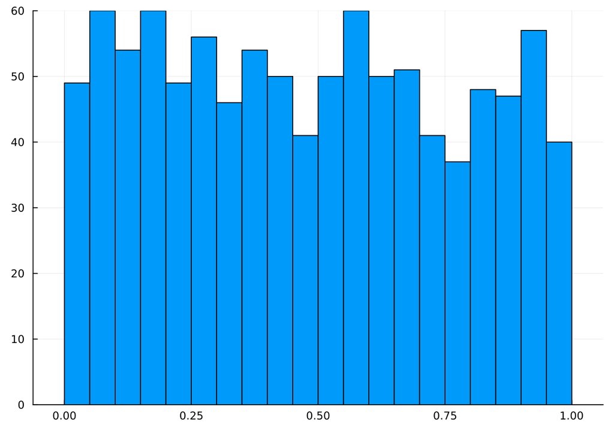

```julia
using Plots

x = Int[]
push!(x, 10)
for i in 1:(10^3 - 1)
  push!(x, linear_congruential(x[i], a = 1664545, c = 1013904223, m = 2^32))
end

histogram(x ./ (2^32); legend = false, bins = 32)
```

Once we have a way of simulating uniform random numbers we can simulate virtually any distribution. We’ll see why in the upcoming notes.

## How to distinguish non-randomness?

- Look for a period in data.
- Are there any values missing systematically from a random stream? Or more rare than you might have expected?
- Look for a proper distribution in the limit.
- Check for autocorrelation.
- Gets harder for higher dimensions…

## Choosing a random device (Optional)

- The random devices in the standard library are chosen for two reasons: they’re incredibly fast and have suitably long periods.
- However, they are subject to buf fixes and performance improvements over time. That means there are no guarantees that `Xoshiro(206)` produces exactly the same sequence in Julia 1.99 as it did in Julia 1.12.
- In practice, we never rely on exact statistical reproducibility because our results should not hold for specific seeds!
- If you truly need full reproducibility, use [StableRNGs](https://github.com/JuliaRandom/StableRNGs.jl) in Julia. The only supported PRNG is the LCG.
- PRNGs for computational applications are rarely cryptographically secure. If you need security, search the Julia package ecosystem for the slower but secure PRNGs.

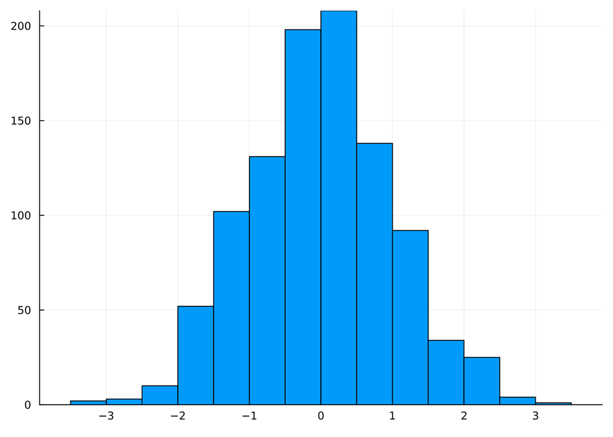

```julia
using StableRNGs

# This is guaranteed to always produce the same sequences.
x = randn(StableRNG(111), 1000)
histogram(x; legend = false)
```